# ML 101 - Lecture 2: Validation, Regularization

### By Arsen Mamikonyan

- Multidimensional OLE regression
- error decomposition into bias and variance
- regularization

## Announcements

- next week Lectures will be at 8pm
- If you don't have personal invite to join webinar and are in the class, email me
- HW0 was graded
- HW1 is out

### Example Problem. How to fit a curve to this?

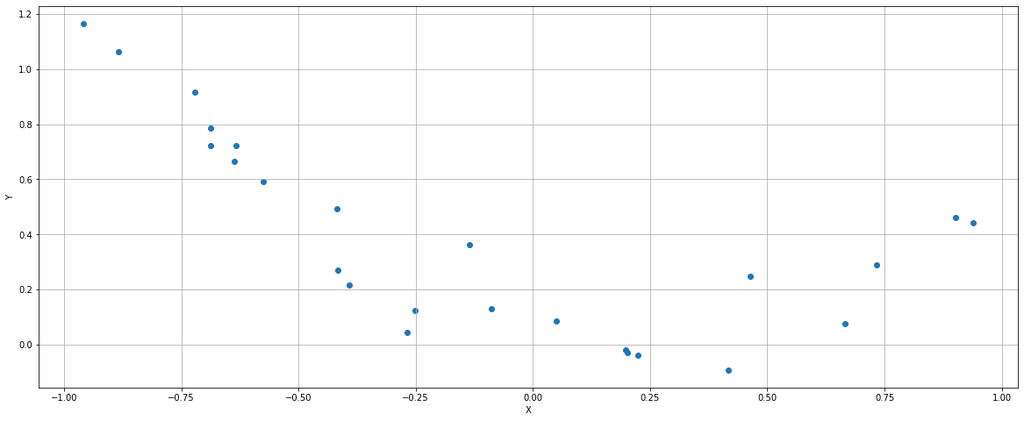

# Ordinary Least Squares in Higher Dimensions

Instead of scalar $x$ we want to have a K-dimensional data vectors $\{x_i\}$,

where $x_i = \begin{bmatrix} x_{i1} \\ x_{i2} \\ \vdots \\ x_{iK} \end{bmatrix}_{K \times 1}$

## $$ \hat{Y_i} = \beta_0 + X_{i1} \beta_1 + X_{i2} \beta_2 + \ldots + X_{iK} \beta_K $$

$$ \begin{bmatrix} Y_1 \\ Y_2 \\ \vdots \\ \vdots \\ Y_N \ \end{bmatrix}_{N\times 1} = \begin{bmatrix} 1 & X_{11} & X_{12} & \ldots & X_{1K}\\ 1 & X_{21} & X_{22} & \ldots & X_{2K}\\ \vdots & \vdots & \vdots & \ldots & \vdots \\ \vdots & \vdots & \vdots & \ldots & \vdots \\ 1 & X_{N1} & X_{N2} & \ldots & X_{NK}\\ \end{bmatrix}_{N\times K+1} \begin{bmatrix} \beta_0 \\ \beta_1 \\ \vdots \\ \vdots \\ \beta_K \end{bmatrix}_{K + 1\times 1} + \begin{bmatrix} \epsilon_1 \\ \epsilon_2 \\ \vdots \\ \vdots \\ \epsilon_N \end{bmatrix}_{N\times 1} $$

This can be rewritten more simply as:

## $$y=X \beta +\epsilon$$

## $y=X \beta +\epsilon$

## $\epsilon = y - X \beta $

## $\text{Loss} = \sum_{i=1}^{N} \epsilon_i^2 = \epsilon^T \epsilon $

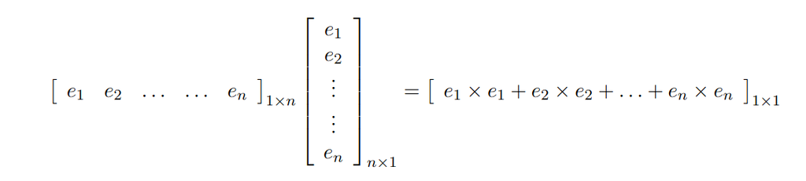

$\text{Loss} = \epsilon^T \epsilon $

$ = (y - X \beta)^T (y - X \beta )$

$ = y^T y - y^T X \beta - \beta^T X^T y + \beta^T X^T X \beta $

Since $y^T X \beta$ is a scalar, $ y^T X \beta = (y^T X \beta)^T = \beta^T X^T y$, so

$ = y^T y - 2 \beta^T X^T y + \beta^T X^T X \beta $

$$ Loss = y^T y - 2 \beta^T X^T y + \beta^T X^T X \beta $$$$ \frac{\partial{Loss}}{\partial{\beta}} = \frac{\partial{\epsilon^T \epsilon}}{\partial{\beta}} = \frac{\partial{(y^T y - 2 \beta^T X^T y + \beta^T X^T X \beta)}}{\partial{\beta}} = -2 X^T y + 2X^T X \beta $$

using $ \frac{\partial{(\beta^T Z \beta)}}{\partial{\beta}} = 2 Z \beta$ and $ \frac{\partial{\beta^T Z}}{\partial{\beta}} = Z$ See https://web.stanford.edu/~mrosenfe/soc_meth_proj3/matrix_OLS_NYU_notes.pdf for details.

Let $\hat{\beta}$ be the extermum point.

### $-2 X^T y + 2X^T X \hat{\beta} = 0 $

### $ X^T y = X^T X \hat{\beta} $

When $X^T X$ is invertible

## $ \hat{\beta} = (X^T X)^{-1}X^T y $

we still need to look at the Hessian to make sure it's a minimum, but it is :)

# How Multinomial is better than scalar?

Since X is multinomial, it can be anything, say polynomial

$$\begin{bmatrix} Y_1 \\ Y_2 \\ \vdots \\ \vdots \\ Y_N \end{bmatrix}_{N\times 1} = \begin{bmatrix} 1 & X_{1} & X_{1}^2 & \ldots & X_{1}^K\\ 1 & X_{1} & X_{2}^2 & \ldots & X_{2}^K\\ \vdots & \vdots & \vdots & \ldots & \vdots \\ \vdots & \vdots & \vdots & \ldots & \vdots \\ 1 & X_{N} & X_{N}^2 & \ldots & X_{N}^K\\ \end{bmatrix}_{N\times K+1} \begin{bmatrix} \beta_0 \\ \beta_1 \\ \vdots \\ \vdots \\ \beta_K \end{bmatrix}_{K + 1\times 1} + \begin{bmatrix} \epsilon_1 \\ \epsilon_2 \\ \vdots \\ \vdots \\ \epsilon_N \end{bmatrix}_{N\times 1} $$

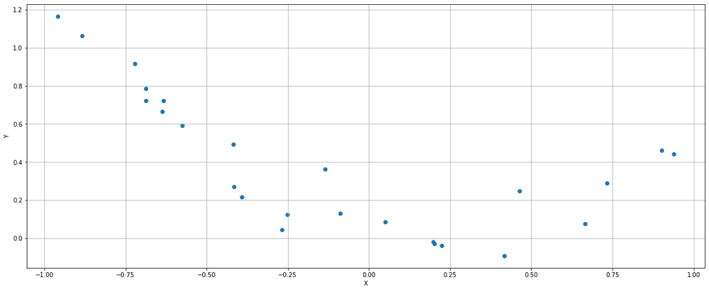

```python
data = generate_data(length=25, seed=42, gaussian_noise=0.1)

plt.scatter(*data)
plt.ylabel('Y')
plt.xlabel('X')
plt.grid()
```

### Transform the data using $\phi(x) = (x, x^2)^T$ and fit a plane.

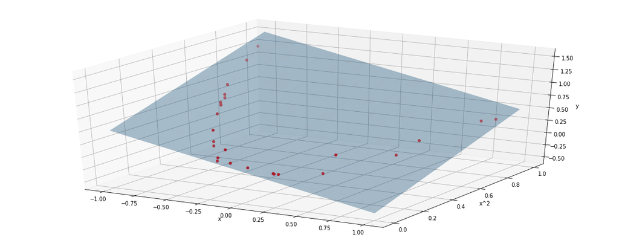

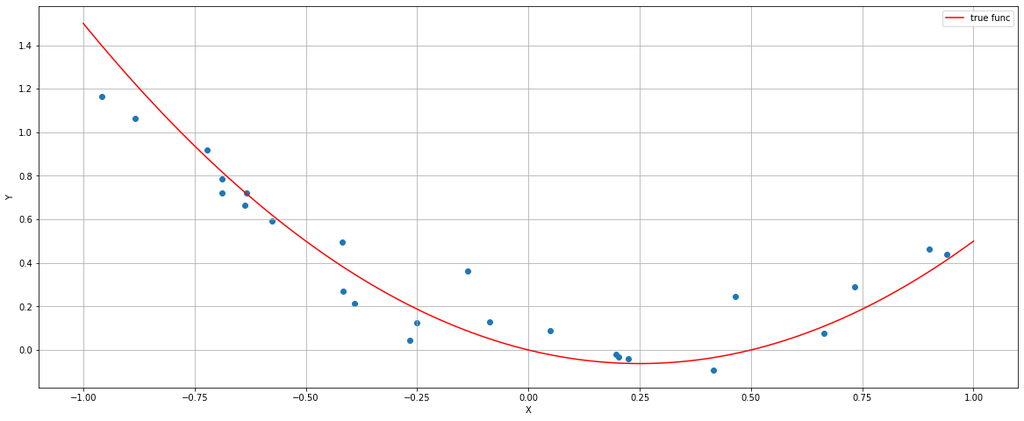

```python
data = generate_data(length=25, seed=42, gaussian_noise=0.1)

plt.scatter(*data)
xx = np.linspace(-1, 1, 100)
plt.plot(xx, -0.5 * xx + xx**2, label='true func', color='red')
plt.ylabel('Y')
plt.xlabel('X')
plt.legend()
plt.grid()
```

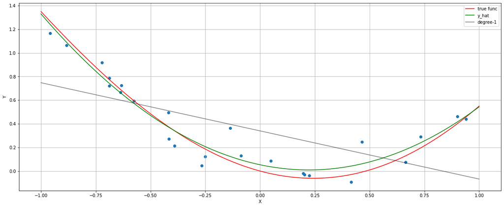

```python
x, y = generate_data(length=25, seed=42, gaussian_noise=0.1)

beta_degree1 = fit_polynomial_regression(x, y, degree=1)

beta_0, beta_1, beta_2 = fit_polynomial_regression(x, y, degree=2)

plt.scatter(x, y)
xx = np.linspace(-1, 1, 100)
plt.plot(xx, true_func(xx), label='true func', color='red')
plt.plot(xx, beta_0 + beta_1 * xx + beta_2 * xx**2, label='y_hat', color='green')
plt.plot(xx, y_hat(xx, beta_degree1), label='degree-1', color='black', alpha=0.5)
plt.ylabel('Y')
plt.xlabel('X')
plt.legend()
plt.grid()
```

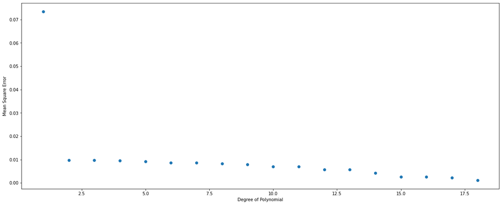

```python
degrees = list(range(1, 19))
losses = []
for k in degrees:
    beta = fit_polynomial_regression(x, y, degree=k)
    losses.append(mean_square_loss(y_hat(x, beta), y))

plt.scatter(degrees, losses)
plt.xlabel('Degree of Polynomial')
plt.ylabel('Mean Square Error');
```

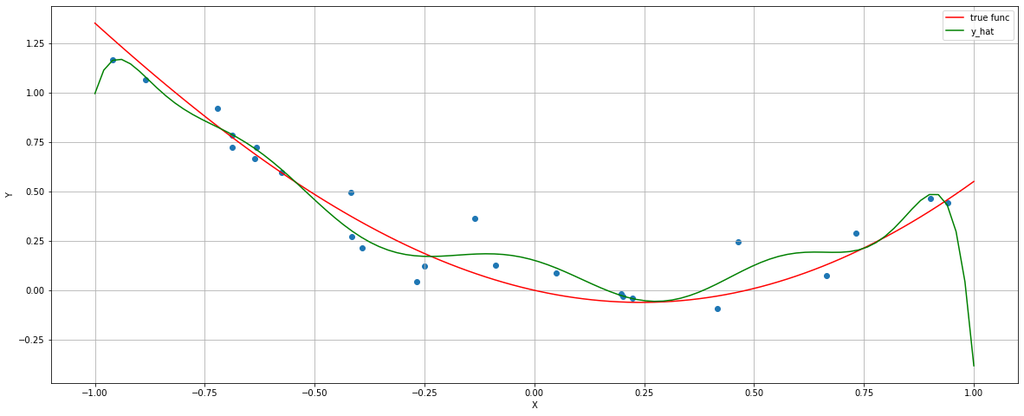

```python
x, y = generate_data(length=25, seed=42, gaussian_noise=0.1)

beta = fit_polynomial_regression(x, y, degree=10)

plt.scatter(x, y)
xx = np.linspace(-1, 1, 100)
plt.plot(xx, true_func(xx), label='true func', color='red')
plt.plot(xx, y_hat(xx, beta), label='y_hat', color='green')
plt.ylabel('Y')
plt.xlabel('X')
plt.legend()
plt.grid()
```

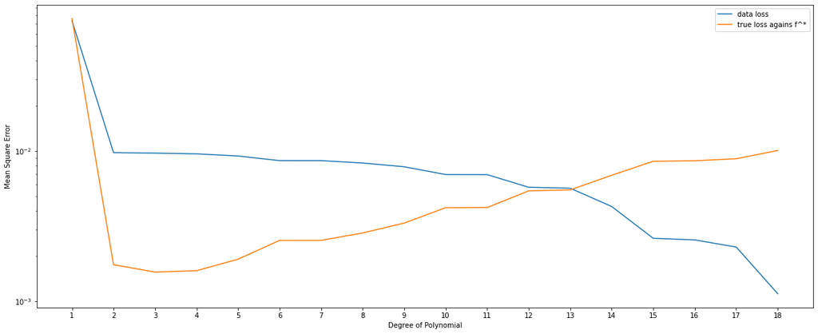

```python
degrees = list(range(1, 19))
losses = []
true_losses = []
for k in degrees:
    beta = fit_polynomial_regression(x, y, degree=k)
    losses.append(mean_square_loss(y_hat(x, beta), y))
    true_losses.append(mean_square_loss(y_hat(x, beta), true_func(x)))

plt.plot(degrees, losses, label='data loss')
plt.plot(degrees, true_losses, label='true loss agains f^*')

plt.xticks(degrees)
plt.legend()
plt.xlabel('Degree of Polynomial')
plt.yscale('log')
plt.ylabel('Mean Square Error');
```

## Adding loss against of test data

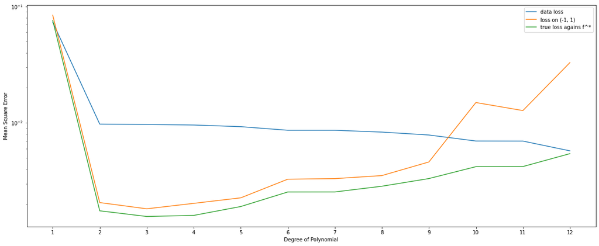

## What is the degree of `true_func`?

# Is this a good estimate?

## Why can't we recover true function without loss?

## And why isn't 4th degree polynomial getting the best answer?

[figure not shown]

```python
def true_func(x):
    return - 0.5 * x + x ** 2 + 0.1 * x ** 3 - 0.05 * x ** 4
```

We assume that there is a function with noise $y = f ( x ) + ε$, where the noise, $\varepsilon $, has zero mean and variance $ \sigma ^{2}$

Exactly how we have modeled our generating function, let's try to understand where does the noise come from.

# Bias Variance

## Notation

- ### $f^*(x)$ := true function
- ### $\hat{\beta}$ estimate of the parameters, for $g(x, \beta)$ that we are trying to find
- ### $\hat{f} := \hat{f}(x, \text{Data}) = g(x, \hat{\beta}) \equiv \hat{y}$ estimate of the function
- ### $y(x) = f^*(x) + \epsilon$

We want to calculate

## $\mathop{\mathbb{E}}_{Data}[(y(x) - \hat{f}(x, Data))^2]$

## $\mathop{\mathbb{E}}_{Data}[(y(x) - \hat{f}(x, Data)^2]$

for simplicity, let's drop arguments,

$\mathop{\mathbb{E}}[(y - \hat{f})^2]$

$ = \mathop{\mathbb{E}}[(f^* + \epsilon - \hat{f})^2]$

add, and subtract $\mathop{\mathbb{E}}[\hat{f}]$

$ = \mathop{\mathbb{E}}[(f^* - \mathop{\mathbb{E}}[\hat{f}] + \epsilon - \hat{f} + \mathop{\mathbb{E}}[\hat{f}] )^2]$

$ = \mathop{\mathbb{E}}[((f^* - \mathop{\mathbb{E}}[\hat{f}]) + \epsilon - (\hat{f} - \mathop{\mathbb{E}}[\hat{f}] ))^2]$

$$ = \mathop{\mathbb{E}}[(f^* - \mathop{\mathbb{E}}[\hat{f}])^2 + \epsilon^2 + (\hat{f} - \mathop{\mathbb{E}}[\hat{f}] )^2 + 2\mathop{\mathbb{E}}[(f^*-\mathop{\mathbb{E}}[\hat{f}])\epsilon] - 2\mathop{\mathbb{E}}[(\hat{f}-\mathop{\mathbb{E}}[\hat{f}])\epsilon]] - 2\mathop{\mathbb{E}}[(f^*-\mathop{\mathbb{E}}[\hat{f}])(\hat{f}-\mathop{\mathbb{E}}[\hat{f}])] $$

Using $\epsilon$ is independent of of data

$$ = Bias[\hat{f}]^2 + Var[\epsilon] + Var[\hat{f}] + 2 \mathop{\mathbb{E}}[\epsilon] \left( \mathop{\mathbb{E}}[(f^*-\mathop{\mathbb{E}}[\hat{f}]) - \mathop{\mathbb{E}}[(\hat{f}-\mathop{\mathbb{E}}[\hat{f}]) \right) + 2(f^* - \mathop{\mathbb{E}}[\hat{f}])\mathop{\mathbb{E}}[(\hat{f}-\mathop{\mathbb{E}}[\hat{f}])$$

Using $ \mathop{\mathbb{E}}[(\hat{f}-\mathop{\mathbb{E}}[\hat{f}] ) = \mathop{\mathbb{E}}[\hat{f}]-\mathop{\mathbb{E}}[\hat{f}] = 0$ , and that $\mathop{\mathbb{E}}[\epsilon] = 0 $

## $\mathop{\mathbb{E}}[(y - \hat{f})^2] = Bias[\hat{f}]^2 + Var[\epsilon] + Var[\hat{f}]$

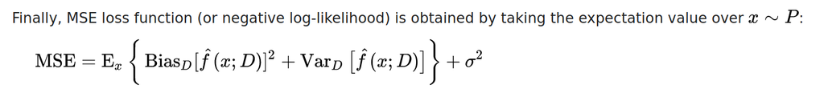

```
 beta_0,  beta_1,  beta_2,  beta_3,  beta_4,  beta_5,  beta_6,  beta_7,  beta_8,  beta_9,  beta_10
   0.08,   -0.33,    1.01,   -0.01,   -0.24
   0.03,   -0.36,    1.24,   -0.16,   -0.39
```

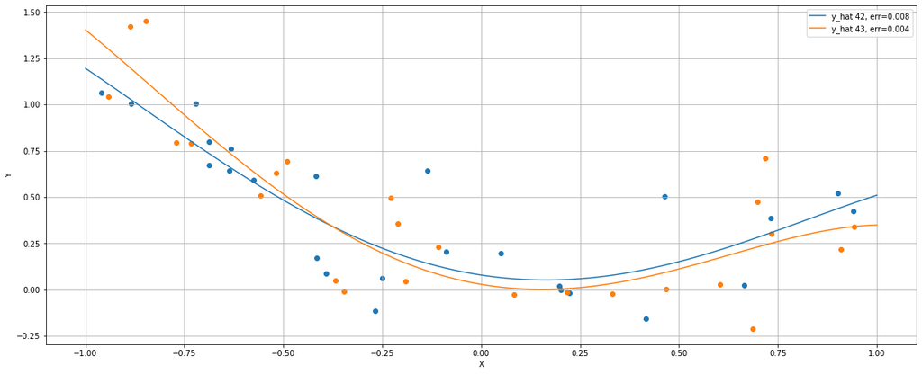

```python
print(', '.join([f' beta_{i}' for i in range(11)]))


for seed in [42, 43]:
    x_s, y_s = generate_data(seed=seed, gaussian_noise=0.2)
    beta = fit_polynomial_regression(x_s, y_s, degree=4)
    print(', '.join([f'{z:7.2f}' for z in beta]))
    plt.scatter(x_s, y_s)
    xx = np.linspace(-1, 1, 100)
    plt.plot(xx, y_hat(xx, beta),
             label=f'y_hat {seed}, err={mean_square_loss(y_hat(xx, beta), true_func(xx)):.3f}')
plt.ylabel('Y')
plt.xlabel('X')
plt.legend()
plt.grid()
```

## Gauss-Markov Theorem

source: https://web.stanford.edu/~mrosenfe/soc_meth_proj3/matrix_OLS_NYU_notes.pdf

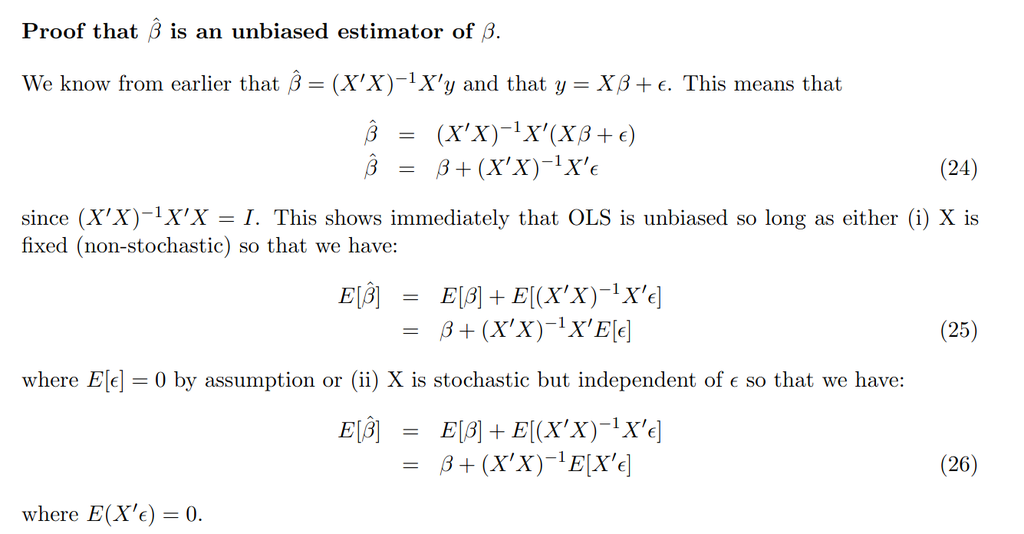

[figure not shown]

# Ridge Regression

We can we increase bias and decrease variance? $\hat{\beta}$ has zero bias

$\text{Loss} = \epsilon^T \epsilon + \lambda \beta^T \beta$

$ = y^T y - 2 \beta^T X^T y + \beta^T X^T X \beta + \lambda \beta^T \beta$

$$ \frac{\partial{Loss}}{\partial{\beta}} = \frac{\partial{(y^T y - 2 \beta^T X^T y + \beta^T X^T X \beta + \lambda \beta^T \beta)}}{\partial{\beta}} = -2 X^T y + 2X^T X \beta + 2 \lambda \beta $$

$-2 X^T y + 2X^T X \hat{\beta} + 2 \lambda \hat{\beta} = 0$

$X^T y = X^T X \hat{\beta} + \lambda \hat{\beta}$

When $X^T X + \lambda I$ is invertible

## $ \hat{\beta} = (X^T X + \lambda I)^{-1}X^T y $

Side effect! It can even work when $X^TX$ is singular.

```
 beta_0,  beta_1,  beta_2,  beta_3,  beta_4,  beta_5,  beta_6,  beta_7,  beta_8,  beta_9,  beta_10
   0.18,   -0.27,    0.42,   -0.09,    0.26,    0.00
   0.16,   -0.28,    0.46,   -0.16,    0.30,   -0.11
```

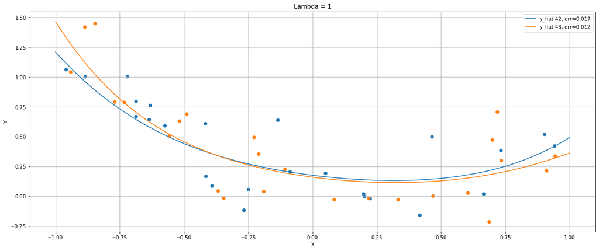

```python
LAMBDA = 1

print(', '.join([f' beta_{i}' for i in range(11)]))


for seed in [42, 43]:
    x_s, y_s = generate_data(seed=seed, gaussian_noise=0.2)
    beta = fit_polynomial_regression(x_s, y_s, degree=5, l=LAMBDA)
    print(', '.join([f'{z:7.2f}' for z in beta]))
    plt.scatter(x_s, y_s)
    xx = np.linspace(-1, 1, 100)
    plt.plot(xx, y_hat(xx, beta),
             label=f'y_hat {seed}, err={mean_square_loss(y_hat(xx, beta), true_func(xx)):.3f}')

plt.ylabel('Y')
plt.xlabel('X')
plt.title(f'Lambda = {LAMBDA}')
plt.legend()
plt.grid()
```

Next time.. Does this help when we don't know the true function we are trying to estimate?